# HACKATHON - I

### HACKATHON - I

#### PROBLEM STATEMENT - Data Analysis on the Banking Sector.

#### IMPORTING THE NECESSARY LIBRARIES

#### NUMPY:

- NumPy stands for Numerical Python.
- NumPy is a Python library used for working with arrays.
- It also has functions for working in domain of linear algebra, fourier transform, and matrices.
- It is an open source project and you can use it freely.

#### PANDAS:

- Pandas is a software library written for the Python programming language for data manipulation and analysis.
- In particular, it offers data structures and operations for manipulating numerical tables and time series.
- It is free software released under the three-clause BSD license.

#### MATPLOTLIB.PYPLOT:

- matplotlib.pyplot is a collection of functions that make matplotlib work like MATLAB.
- Each pyplot function makes some change to a figure: e.g., creates a figure, creates a plotting area in a figure, plots some lines in a plotting area, decorates the plot with labels, etc.

#### SEABORN:

- Seaborn is a Python data visualization library based on matplotlib.
- It provides a high-level interface for drawing attractive and informative statistical graphics.
- For a brief introduction to the ideas behind the library, you can read the introductory notes.

#### PLOTLY:

- Plotly allows users to import, copy and paste, or stream data to be analyzed and visualized.
- The Plotly Python graphing library is a scientific graphing library.
- Graphs can be styled with Python and a GUI, and shared with a URL for others to view, collaborate, or save a copy.

#### RE:

- A regular expression (or) RE specifies a set of strings that matches it.
- The functions in this module let us check if a particular string matches a given regular expression (or) if a given regular expression matches a particular string, which comes down to the same thing.

```python
import numpy as np
import pandas as pd
import matplotlib.pyplot as plt
import seaborn as sns
import plotly.express as px
import re
```

#### IMPORTING & READING THE EXCEL FILE

```python
df = pd.read_csv(r'C:\Users\admin\Downloads\DATASETS/BankingData.csv')
df
```

|  | banking marketing | Unnamed: 1 | Unnamed: 2 | Unnamed: 3 | Unnamed: 4 | Unnamed: 5 | Unnamed: 6 | Unnamed: 7 | Unnamed: 8 | Unnamed: 9 | Unnamed: 10 | Unnamed: 11 | Unnamed: 12 | Unnamed: 13 | Unnamed: 14 | Unnamed: 15 | Unnamed: 16 | Unnamed: 17 | Unnamed: 18 |
| --- | --- | --- | --- | --- | --- | --- | --- | --- | --- | --- | --- | --- | --- | --- | --- | --- | --- | --- | --- |
| 0 | customer id and age. | NaN | Customer salary and balance. | NaN | Customer marital status and job with education... | NaN | particular customer before targeted or not | NaN | Loan types: loans or housing loans | NaN | Contact type | NaN | month of contact | duration of call | NaN | NaN | NaN | outcome of previous contact | response of customer after call happned |
| 1 | customerid | age | salary | balance | marital | jobedu | targeted | default | housing | loan | contact | day | month | duration | campaign | pdays | previous | poutcome | response |
| 2 | 1 | 58 | 100000 | 2143 | married | management,tertiary | yes | no | yes | no | unknown | 5 | may, 2017 | 261 sec | 1 | -1 | 0 | unknown | no |
| 3 | 2 | 44 | 60000 | 29 | single | technician,secondary | yes | no | yes | no | unknown | 5 | may, 2017 | 151 sec | 1 | -1 | 0 | unknown | no |
| 4 | 3 | 33 | 120000 | 2 | married | entrepreneur,secondary | yes | no | yes | yes | unknown | 5 | may, 2017 | 76 sec | 1 | -1 | 0 | unknown | no |
| ... | ... | ... | ... | ... | ... | ... | ... | ... | ... | ... | ... | ... | ... | ... | ... | ... | ... | ... | ... |
| 45208 | 45207 | 51 | 60000 | 825 | married | technician,tertiary | yes | no | no | no | cellular | 17 | nov, 2017 | 16.2833333333333 min | 3 | -1 | 0 | unknown | yes |
| 45209 | 45208 | 71 | 55000 | 1729 | divorced | retired,primary | yes | no | no | no | cellular | 17 | nov, 2017 | 7.6 min | 2 | -1 | 0 | unknown | yes |
| 45210 | 45209 | 72 | 55000 | 5715 | married | retired,secondary | yes | no | no | no | cellular | 17 | nov, 2017 | 18.7833333333333 min | 5 | 184 | 3 | success | yes |
| 45211 | 45210 | 57 | 20000 | 668 | married | blue-collar,secondary | yes | no | no | no | telephone | 17 | nov, 2017 | 8.46666666666667 min | 4 | -1 | 0 | unknown | no |
| 45212 | 45211 | 37 | 120000 | 2971 | married | entrepreneur,secondary | yes | no | no | no | cellular | 17 | nov, 2017 | 6.01666666666667 min | 2 | 188 | 11 | other | no |

45213 rows × 19 columns

#### SHAPE OF THE DATAFRAME:

- The shape attribute of pandas.
- DataFrame stores the number of rows and columns as a tuple (number of rows, number of columns)

```python
df.shape
```

```
(45213, 19)
```

#### describe() function:

- Pandas describe() is used to view some basic statistical details like percentile, mean, std etc. of a data frame or a series of numeric values.
- When this method is applied to a series of string, it returns a different output which is shown below.

#### include = 'all' function:

- It provides as an option, the result will include a union of attributes of each type.
- The includes and excludes parameters, can be used to limit which columns in a DataFrame are analyzed for the output.
- The parameters are ignored when analyzing a Series & describes a numeric Series.

```python
df.describe(include = "all")
```

|  | banking marketing | Unnamed: 1 | Unnamed: 2 | Unnamed: 3 | Unnamed: 4 | Unnamed: 5 | Unnamed: 6 | Unnamed: 7 | Unnamed: 8 | Unnamed: 9 | Unnamed: 10 | Unnamed: 11 | Unnamed: 12 | Unnamed: 13 | Unnamed: 14 | Unnamed: 15 | Unnamed: 16 | Unnamed: 17 | Unnamed: 18 |
| --- | --- | --- | --- | --- | --- | --- | --- | --- | --- | --- | --- | --- | --- | --- | --- | --- | --- | --- | --- |
| count | 45213 | 45192 | 45213 | 45212 | 45213 | 45212 | 45213 | 45212 | 45213 | 45212 | 45213 | 45212 | 45163 | 45213 | 45212 | 45212 | 45212 | 45213 | 45183 |
| unique | 45213 | 145 | 14 | 10335 | 5 | 49 | 4 | 3 | 4 | 3 | 5 | 63 | 14 | 2648 | 67 | 837 | 72 | 6 | 4 |
| top | 5639 | 32 | 20000 | 0 | married | management,tertiary | yes | no | yes | no | cellular | 20 | may, 2017 | 1.5 min | 1 | -1 | 0 | unknown | no |
| freq | 1 | 1509 | 9732 | 2767 | 27214 | 7801 | 37091 | 44396 | 25130 | 37967 | 29285 | 2030 | 13747 | 138 | 11502 | 30277 | 30277 | 36959 | 39894 |

#### OBSERVATION:

- We are able to get the information of COUNT, UNIQUE, TOP, FREQUENCY entire data.

#### head() function:

- The head() function is used to get the first n rows.
- This function returns the first n rows for the object based on position.
- It is useful for quickly testing if your object has the right type of data in it.
- The first n rows of the caller object.

```python
df.head()
```

|  | banking marketing | Unnamed: 1 | Unnamed: 2 | Unnamed: 3 | Unnamed: 4 | Unnamed: 5 | Unnamed: 6 | Unnamed: 7 | Unnamed: 8 | Unnamed: 9 | Unnamed: 10 | Unnamed: 11 | Unnamed: 12 | Unnamed: 13 | Unnamed: 14 | Unnamed: 15 | Unnamed: 16 | Unnamed: 17 | Unnamed: 18 |
| --- | --- | --- | --- | --- | --- | --- | --- | --- | --- | --- | --- | --- | --- | --- | --- | --- | --- | --- | --- |
| 0 | customer id and age. | NaN | Customer salary and balance. | NaN | Customer marital status and job with education... | NaN | particular customer before targeted or not | NaN | Loan types: loans or housing loans | NaN | Contact type | NaN | month of contact | duration of call | NaN | NaN | NaN | outcome of previous contact | response of customer after call happned |
| 1 | customerid | age | salary | balance | marital | jobedu | targeted | default | housing | loan | contact | day | month | duration | campaign | pdays | previous | poutcome | response |
| 2 | 1 | 58 | 100000 | 2143 | married | management,tertiary | yes | no | yes | no | unknown | 5 | may, 2017 | 261 sec | 1 | -1 | 0 | unknown | no |
| 3 | 2 | 44 | 60000 | 29 | single | technician,secondary | yes | no | yes | no | unknown | 5 | may, 2017 | 151 sec | 1 | -1 | 0 | unknown | no |
| 4 | 3 | 33 | 120000 | 2 | married | entrepreneur,secondary | yes | no | yes | yes | unknown | 5 | may, 2017 | 76 sec | 1 | -1 | 0 | unknown | no |

#### tail() function:

- The tail() function is used to get the last n rows.
- This function returns last n rows from the object based on position.
- It is useful for quickly verifying data, for example, after sorting or appending rows.
- The last n rows of the caller object.

```python
df.tail()
```

|  | banking marketing | Unnamed: 1 | Unnamed: 2 | Unnamed: 3 | Unnamed: 4 | Unnamed: 5 | Unnamed: 6 | Unnamed: 7 | Unnamed: 8 | Unnamed: 9 | Unnamed: 10 | Unnamed: 11 | Unnamed: 12 | Unnamed: 13 | Unnamed: 14 | Unnamed: 15 | Unnamed: 16 | Unnamed: 17 | Unnamed: 18 |
| --- | --- | --- | --- | --- | --- | --- | --- | --- | --- | --- | --- | --- | --- | --- | --- | --- | --- | --- | --- |
| 45208 | 45207 | 51 | 60000 | 825 | married | technician,tertiary | yes | no | no | no | cellular | 17 | nov, 2017 | 16.2833333333333 min | 3 | -1 | 0 | unknown | yes |
| 45209 | 45208 | 71 | 55000 | 1729 | divorced | retired,primary | yes | no | no | no | cellular | 17 | nov, 2017 | 7.6 min | 2 | -1 | 0 | unknown | yes |
| 45210 | 45209 | 72 | 55000 | 5715 | married | retired,secondary | yes | no | no | no | cellular | 17 | nov, 2017 | 18.7833333333333 min | 5 | 184 | 3 | success | yes |
| 45211 | 45210 | 57 | 20000 | 668 | married | blue-collar,secondary | yes | no | no | no | telephone | 17 | nov, 2017 | 8.46666666666667 min | 4 | -1 | 0 | unknown | no |
| 45212 | 45211 | 37 | 120000 | 2971 | married | entrepreneur,secondary | yes | no | no | no | cellular | 17 | nov, 2017 | 6.01666666666667 min | 2 | 188 | 11 | other | no |

#### REPLACING MISSING VALUES

#### MISSING VALUES:

- In Python, specifically Pandas, NumPy and Scikit-Learn, we mark missing values as NaN.
- Values with a NaN value are ignored from operations like sum, count, etc.
- Running the example prints the number of missing values in each column.
- In statistics, missing data, or missing values, occur when no data value is stored for the variable in an observation.
- Sometimes missing values are caused by the researcher—for example, when data collection is done improperly or mistakes are made in data entry.

#### METHOD FOR REPLACIG MISSING VALUES:

- value : value to use to replace NaN.
- method : method to use for replacing NaN. method = 'ffill' does the forward replacement & method = 'bfill' does the backword replacement.
- axis : 0 for row and 1 for column.
- inplace : If True, do operation inplace and return None.

```python
missing_val = ['n/a','-','?',' ']
df = pd.read_csv(r'C:\Users\admin\Downloads\DATASETS/BankingData.csv', na_values = missing_val)
df
```

|  | banking marketing | Unnamed: 1 | Unnamed: 2 | Unnamed: 3 | Unnamed: 4 | Unnamed: 5 | Unnamed: 6 | Unnamed: 7 | Unnamed: 8 | Unnamed: 9 | Unnamed: 10 | Unnamed: 11 | Unnamed: 12 | Unnamed: 13 | Unnamed: 14 | Unnamed: 15 | Unnamed: 16 | Unnamed: 17 | Unnamed: 18 |
| --- | --- | --- | --- | --- | --- | --- | --- | --- | --- | --- | --- | --- | --- | --- | --- | --- | --- | --- | --- |
| 0 | customer id and age. | NaN | Customer salary and balance. | NaN | Customer marital status and job with education... | NaN | particular customer before targeted or not | NaN | Loan types: loans or housing loans | NaN | Contact type | NaN | month of contact | duration of call | NaN | NaN | NaN | outcome of previous contact | response of customer after call happned |
| 1 | customerid | age | salary | balance | marital | jobedu | targeted | default | housing | loan | contact | day | month | duration | campaign | pdays | previous | poutcome | response |
| 2 | 1 | 58 | 100000 | 2143 | married | management,tertiary | yes | no | yes | no | unknown | 5 | may, 2017 | 261 sec | 1 | -1 | 0 | unknown | no |
| 3 | 2 | 44 | 60000 | 29 | single | technician,secondary | yes | no | yes | no | unknown | 5 | may, 2017 | 151 sec | 1 | -1 | 0 | unknown | no |
| 4 | 3 | 33 | 120000 | 2 | married | entrepreneur,secondary | yes | no | yes | yes | unknown | 5 | may, 2017 | 76 sec | 1 | -1 | 0 | unknown | no |
| ... | ... | ... | ... | ... | ... | ... | ... | ... | ... | ... | ... | ... | ... | ... | ... | ... | ... | ... | ... |
| 45208 | 45207 | 51 | 60000 | 825 | married | technician,tertiary | yes | no | no | no | cellular | 17 | nov, 2017 | 16.2833333333333 min | 3 | -1 | 0 | unknown | yes |
| 45209 | 45208 | 71 | 55000 | 1729 | divorced | retired,primary | yes | no | no | no | cellular | 17 | nov, 2017 | 7.6 min | 2 | -1 | 0 | unknown | yes |
| 45210 | 45209 | 72 | 55000 | 5715 | married | retired,secondary | yes | no | no | no | cellular | 17 | nov, 2017 | 18.7833333333333 min | 5 | 184 | 3 | success | yes |
| 45211 | 45210 | 57 | 20000 | 668 | married | blue-collar,secondary | yes | no | no | no | telephone | 17 | nov, 2017 | 8.46666666666667 min | 4 | -1 | 0 | unknown | no |
| 45212 | 45211 | 37 | 120000 | 2971 | married | entrepreneur,secondary | yes | no | no | no | cellular | 17 | nov, 2017 | 6.01666666666667 min | 2 | 188 | 11 | other | no |

45213 rows × 19 columns

#### CHANGING THE COLUMN NAMES

##### df.column function:

- Pandas DataFrame is a two-dimensional size-mutable, potentially heterogeneous tabular data structure with labeled axes (rows and columns).
- Arithmetic operations align on both row and column labels.
- It can be thought of as a dict-like container for Series objects.
- This is the primary data structure of the Pandas.

```python
df.columns
```

```
Index(['banking marketing', 'Unnamed: 1', 'Unnamed: 2', 'Unnamed: 3',
       'Unnamed: 4', 'Unnamed: 5', 'Unnamed: 6', 'Unnamed: 7', 'Unnamed: 8',
       'Unnamed: 9', 'Unnamed: 10', 'Unnamed: 11', 'Unnamed: 12',
       'Unnamed: 13', 'Unnamed: 14', 'Unnamed: 15', 'Unnamed: 16',
       'Unnamed: 17', 'Unnamed: 18'],
      dtype='object')
```

```python
df.columns = ['customer_id','age','salary','balance','marital','jobedu','targeted','default','housing','loan','contact','day','month','duration','campaign','pdays','previous','poutcome',
            'response']
df
```

|  | customer_id | age | salary | balance | marital | jobedu | targeted | default | housing | loan | contact | day | month | duration | campaign | pdays | previous | poutcome | response |
| --- | --- | --- | --- | --- | --- | --- | --- | --- | --- | --- | --- | --- | --- | --- | --- | --- | --- | --- | --- |
| 0 | customer id and age. | NaN | Customer salary and balance. | NaN | Customer marital status and job with education... | NaN | particular customer before targeted or not | NaN | Loan types: loans or housing loans | NaN | Contact type | NaN | month of contact | duration of call | NaN | NaN | NaN | outcome of previous contact | response of customer after call happned |
| 1 | customerid | age | salary | balance | marital | jobedu | targeted | default | housing | loan | contact | day | month | duration | campaign | pdays | previous | poutcome | response |
| 2 | 1 | 58 | 100000 | 2143 | married | management,tertiary | yes | no | yes | no | unknown | 5 | may, 2017 | 261 sec | 1 | -1 | 0 | unknown | no |
| 3 | 2 | 44 | 60000 | 29 | single | technician,secondary | yes | no | yes | no | unknown | 5 | may, 2017 | 151 sec | 1 | -1 | 0 | unknown | no |
| 4 | 3 | 33 | 120000 | 2 | married | entrepreneur,secondary | yes | no | yes | yes | unknown | 5 | may, 2017 | 76 sec | 1 | -1 | 0 | unknown | no |
| ... | ... | ... | ... | ... | ... | ... | ... | ... | ... | ... | ... | ... | ... | ... | ... | ... | ... | ... | ... |
| 45208 | 45207 | 51 | 60000 | 825 | married | technician,tertiary | yes | no | no | no | cellular | 17 | nov, 2017 | 16.2833333333333 min | 3 | -1 | 0 | unknown | yes |
| 45209 | 45208 | 71 | 55000 | 1729 | divorced | retired,primary | yes | no | no | no | cellular | 17 | nov, 2017 | 7.6 min | 2 | -1 | 0 | unknown | yes |
| 45210 | 45209 | 72 | 55000 | 5715 | married | retired,secondary | yes | no | no | no | cellular | 17 | nov, 2017 | 18.7833333333333 min | 5 | 184 | 3 | success | yes |
| 45211 | 45210 | 57 | 20000 | 668 | married | blue-collar,secondary | yes | no | no | no | telephone | 17 | nov, 2017 | 8.46666666666667 min | 4 | -1 | 0 | unknown | no |
| 45212 | 45211 | 37 | 120000 | 2971 | married | entrepreneur,secondary | yes | no | no | no | cellular | 17 | nov, 2017 | 6.01666666666667 min | 2 | 188 | 11 | other | no |

45213 rows × 19 columns

#### DROPPING UNNECESSARY ROWS

#### drop() function:

- The drop() function is used to drop specified labels from rows or columns.
- Remove rows or columns by specifying label names and corresponding axis, or by specifying directly index or column names.
- When using a multi-index, labels on different levels can be removed by specifying the level.

#### HOW TO DROP A ROW?

- drop("Area", axis = 1, inplace = True).
- Rows can also be removed using the “drop” function, by specifying axis = 0.
- Drop() removes rows based on “labels”, rather than numeric indexing.
- To delete rows based on their numeric position/index, use iloc to reassign the dataframe values, as in the below.

#### inplace = True function:

- When inplace = True, the data is modified in place, which means it will return nothing and the dataframe is now updated.
- When inplace = False , which is the default, then the operation is performed and it returns a copy of the object. You then need to save it to something.

```python
df.drop([0,1], inplace = True)
df
```

|  | customer_id | age | salary | balance | marital | jobedu | targeted | default | housing | loan | contact | day | month | duration | campaign | pdays | previous | poutcome | response |
| --- | --- | --- | --- | --- | --- | --- | --- | --- | --- | --- | --- | --- | --- | --- | --- | --- | --- | --- | --- |
| 2 | 1 | 58 | 100000 | 2143 | married | management,tertiary | yes | no | yes | no | unknown | 5 | may, 2017 | 261 sec | 1 | -1 | 0 | unknown | no |
| 3 | 2 | 44 | 60000 | 29 | single | technician,secondary | yes | no | yes | no | unknown | 5 | may, 2017 | 151 sec | 1 | -1 | 0 | unknown | no |
| 4 | 3 | 33 | 120000 | 2 | married | entrepreneur,secondary | yes | no | yes | yes | unknown | 5 | may, 2017 | 76 sec | 1 | -1 | 0 | unknown | no |
| 5 | 4 | 47 | 20000 | 1506 | married | blue-collar,unknown | no | no | yes | no | unknown | 5 | may, 2017 | 92 sec | 1 | -1 | 0 | unknown | no |
| 6 | 5 | 33 | 0 | 1 | single | unknown,unknown | no | no | no | no | unknown | 5 | may, 2017 | 198 sec | 1 | -1 | 0 | unknown | no |
| ... | ... | ... | ... | ... | ... | ... | ... | ... | ... | ... | ... | ... | ... | ... | ... | ... | ... | ... | ... |
| 45208 | 45207 | 51 | 60000 | 825 | married | technician,tertiary | yes | no | no | no | cellular | 17 | nov, 2017 | 16.2833333333333 min | 3 | -1 | 0 | unknown | yes |
| 45209 | 45208 | 71 | 55000 | 1729 | divorced | retired,primary | yes | no | no | no | cellular | 17 | nov, 2017 | 7.6 min | 2 | -1 | 0 | unknown | yes |
| 45210 | 45209 | 72 | 55000 | 5715 | married | retired,secondary | yes | no | no | no | cellular | 17 | nov, 2017 | 18.7833333333333 min | 5 | 184 | 3 | success | yes |
| 45211 | 45210 | 57 | 20000 | 668 | married | blue-collar,secondary | yes | no | no | no | telephone | 17 | nov, 2017 | 8.46666666666667 min | 4 | -1 | 0 | unknown | no |
| 45212 | 45211 | 37 | 120000 | 2971 | married | entrepreneur,secondary | yes | no | no | no | cellular | 17 | nov, 2017 | 6.01666666666667 min | 2 | 188 | 11 | other | no |

45211 rows × 19 columns

#### REST INDEX:

- Pandas reset_index() is a method to reset index of a Data Frame.
- reset_index() method sets a list of integer ranging from 0 to length of data as index.
- For a Series with a MultiIndex, only remove the specified levels from the index & Removes all levels by default.
- Just reset the index, without inserting it as a column in the new DataFrame.
- Parameters: level: int, string or a list to select and remove passed column from index

```python
df = df.reset_index()
df
```

|  | index | customer_id | age | salary | balance | marital | jobedu | targeted | default | housing | loan | contact | day | month | duration | campaign | pdays | previous | poutcome | response |
| --- | --- | --- | --- | --- | --- | --- | --- | --- | --- | --- | --- | --- | --- | --- | --- | --- | --- | --- | --- | --- |
| 0 | 2 | 1 | 58 | 100000 | 2143 | married | management,tertiary | yes | no | yes | no | unknown | 5 | may, 2017 | 261 sec | 1 | -1 | 0 | unknown | no |
| 1 | 3 | 2 | 44 | 60000 | 29 | single | technician,secondary | yes | no | yes | no | unknown | 5 | may, 2017 | 151 sec | 1 | -1 | 0 | unknown | no |
| 2 | 4 | 3 | 33 | 120000 | 2 | married | entrepreneur,secondary | yes | no | yes | yes | unknown | 5 | may, 2017 | 76 sec | 1 | -1 | 0 | unknown | no |
| 3 | 5 | 4 | 47 | 20000 | 1506 | married | blue-collar,unknown | no | no | yes | no | unknown | 5 | may, 2017 | 92 sec | 1 | -1 | 0 | unknown | no |
| 4 | 6 | 5 | 33 | 0 | 1 | single | unknown,unknown | no | no | no | no | unknown | 5 | may, 2017 | 198 sec | 1 | -1 | 0 | unknown | no |
| ... | ... | ... | ... | ... | ... | ... | ... | ... | ... | ... | ... | ... | ... | ... | ... | ... | ... | ... | ... | ... |
| 45206 | 45208 | 45207 | 51 | 60000 | 825 | married | technician,tertiary | yes | no | no | no | cellular | 17 | nov, 2017 | 16.2833333333333 min | 3 | -1 | 0 | unknown | yes |
| 45207 | 45209 | 45208 | 71 | 55000 | 1729 | divorced | retired,primary | yes | no | no | no | cellular | 17 | nov, 2017 | 7.6 min | 2 | -1 | 0 | unknown | yes |
| 45208 | 45210 | 45209 | 72 | 55000 | 5715 | married | retired,secondary | yes | no | no | no | cellular | 17 | nov, 2017 | 18.7833333333333 min | 5 | 184 | 3 | success | yes |
| 45209 | 45211 | 45210 | 57 | 20000 | 668 | married | blue-collar,secondary | yes | no | no | no | telephone | 17 | nov, 2017 | 8.46666666666667 min | 4 | -1 | 0 | unknown | no |
| 45210 | 45212 | 45211 | 37 | 120000 | 2971 | married | entrepreneur,secondary | yes | no | no | no | cellular | 17 | nov, 2017 | 6.01666666666667 min | 2 | 188 | 11 | other | no |

45211 rows × 20 columns

#### DELETING THE UNNECESSARY COLUMNS IN DATAFRAME

#### del function:

- The del keyword is used to delete objects.
- In Python everything is an object, so the del keyword can also be used to delete variables, lists, or parts of a list etc.

#### DIFFERENCE BETWEEN REMOVE & DELETE FUNCTION:

- remove(): delete the matching element/object.
- del and pop removes the element at a specific index.
- del and pop deals with the index.
- The only difference between two is that- pop return deleted the value from the list and del does not return anything.
- Pop is only way that returns the object.

```python
del df['index']
df
```

|  | customer_id | age | salary | balance | marital | jobedu | targeted | default | housing | loan | contact | day | month | duration | campaign | pdays | previous | poutcome | response |
| --- | --- | --- | --- | --- | --- | --- | --- | --- | --- | --- | --- | --- | --- | --- | --- | --- | --- | --- | --- |
| 0 | 1 | 58 | 100000 | 2143 | married | management,tertiary | yes | no | yes | no | unknown | 5 | may, 2017 | 261 sec | 1 | -1 | 0 | unknown | no |
| 1 | 2 | 44 | 60000 | 29 | single | technician,secondary | yes | no | yes | no | unknown | 5 | may, 2017 | 151 sec | 1 | -1 | 0 | unknown | no |
| 2 | 3 | 33 | 120000 | 2 | married | entrepreneur,secondary | yes | no | yes | yes | unknown | 5 | may, 2017 | 76 sec | 1 | -1 | 0 | unknown | no |
| 3 | 4 | 47 | 20000 | 1506 | married | blue-collar,unknown | no | no | yes | no | unknown | 5 | may, 2017 | 92 sec | 1 | -1 | 0 | unknown | no |
| 4 | 5 | 33 | 0 | 1 | single | unknown,unknown | no | no | no | no | unknown | 5 | may, 2017 | 198 sec | 1 | -1 | 0 | unknown | no |
| ... | ... | ... | ... | ... | ... | ... | ... | ... | ... | ... | ... | ... | ... | ... | ... | ... | ... | ... | ... |
| 45206 | 45207 | 51 | 60000 | 825 | married | technician,tertiary | yes | no | no | no | cellular | 17 | nov, 2017 | 16.2833333333333 min | 3 | -1 | 0 | unknown | yes |
| 45207 | 45208 | 71 | 55000 | 1729 | divorced | retired,primary | yes | no | no | no | cellular | 17 | nov, 2017 | 7.6 min | 2 | -1 | 0 | unknown | yes |
| 45208 | 45209 | 72 | 55000 | 5715 | married | retired,secondary | yes | no | no | no | cellular | 17 | nov, 2017 | 18.7833333333333 min | 5 | 184 | 3 | success | yes |
| 45209 | 45210 | 57 | 20000 | 668 | married | blue-collar,secondary | yes | no | no | no | telephone | 17 | nov, 2017 | 8.46666666666667 min | 4 | -1 | 0 | unknown | no |
| 45210 | 45211 | 37 | 120000 | 2971 | married | entrepreneur,secondary | yes | no | no | no | cellular | 17 | nov, 2017 | 6.01666666666667 min | 2 | 188 | 11 | other | no |

45211 rows × 19 columns

#### TREATING MISSING VALUES

#### isnull() function:

- It detect missing values in the given series object.
- It return a boolean same-sized object indicating if the values are NA.
- Missing values gets mapped to True and non-missing value gets mapped to False.

#### What is the use of isnull () method in pandas?

- The isnull() function is used to detect missing values for an array-like object.
- This function takes a scalar or array-like object and indicates whether values are missing (NaN in numeric arrays, None or NaN in object arrays, NaT in datetimelike).
- Object to check for null or missing values.

#### df.isnull().sum() function:

- returns the number of missing values in the data set.
- A simple way to deal with data containing missing values is to skip rows with missing values in the dataset.

```python
df.isnull().sum()
```

```
customer_id     0
age            20
salary         62
balance         0
marital         0
jobedu          0
targeted        0
default         0
housing         0
loan            0
contact         0
day             0
month          50
duration        0
campaign        0
pdays           0
previous        0
poutcome        0
response       30
dtype: int64
```

```python
df.isnull().any(axis=0)
```

```
customer_id    False
age             True
salary          True
balance        False
marital        False
jobedu         False
targeted       False
default        False
housing        False
loan           False
contact        False
day            False
month           True
duration       False
campaign       False
pdays          False
previous       False
poutcome       False
response        True
dtype: bool
```

#### info() function:

- The info() function is used to print a concise summary of a DataFrame.
- This method prints information about a DataFrame including the index dtype and column dtypes, non-null values and memory usage.

```python
df.info()
```

```
<class 'pandas.core.frame.DataFrame'>
RangeIndex: 45211 entries, 0 to 45210
Data columns (total 19 columns):
 #   Column       Non-Null Count  Dtype
---  ------       --------------  -----
 0   customer_id  45211 non-null  object
 1   age          45191 non-null  object
 2   salary       45149 non-null  object
 3   balance      45211 non-null  object
 4   marital      45211 non-null  object
 5   jobedu       45211 non-null  object
 6   targeted     45211 non-null  object
 7   default      45211 non-null  object
 8   housing      45211 non-null  object
 9   loan         45211 non-null  object
 10  contact      45211 non-null  object
 11  day          45211 non-null  object
 12  month        45161 non-null  object
 13  duration     45211 non-null  object
 14  campaign     45211 non-null  object
 15  pdays        45211 non-null  object
 16  previous     45211 non-null  object
 17  poutcome     45211 non-null  object
 18  response     45181 non-null  object
dtypes: object(19)
memory usage: 6.6+ MB
```

#### value_count() function:

- The value_counts() function is used to get a Series containing counts of unique values.
- The resulting object will be in descending order so that the first element is the most frequently-occurring element.
- Excludes NA values by default.

```python
df.salary.value_counts()
```

```
20000       7290
60000       7036
100000      6890
50000       3517
70000       3078
100000.0    2568
20000.0     2442
60000.0     2140
50000.0     1654
55000       1267
120000      1189
70000.0     1076
55000.0      997
16000        987
8000         972
4000.0       620
8000.0       331
4000         318
120000.0     298
16000.0      253
0            174
0.0           52
Name: salary, dtype: int64
```

```python
df.poutcome.value_counts()
```

```
unknown    36959
failure     4901
other       1840
success     1511
Name: poutcome, dtype: int64
```

#### USING FILLNA FUNCTION

#### fillna() function:

- fillna() function to fill out the missing values in the given series object.
- Use a dictionary to pass the values to be filled corresponding to the different index labels in the series object.

#### What is the use of fillna in Python?

- The fillna() function is used to fill NA/NaN values using the specified method.
- Value to use to fill holes (e.g. 0), alternately a dict/Series/DataFrame of values specifying which value to use for each index for a Series (or) column for a DataFrame.
- Values not in the dict/Series/DataFrame will not be filled.

```python
round(100*(df.isnull().sum()/len(df.index)), 2)
```

```
customer_id    0.00
age            0.04
salary         0.14
balance        0.00
marital        0.00
jobedu         0.00
targeted       0.00
default        0.00
housing        0.00
loan           0.00
contact        0.00
day            0.00
month          0.11
duration       0.00
campaign       0.00
pdays          0.00
previous       0.00
poutcome       0.00
response       0.07
dtype: float64
```

```python
df.age.value_counts()
```

```
32      1509
31      1487
33      1393
35      1359
34      1351
        ...
82         2
94         1
90.0       1
86         1
90         1
Name: age, Length: 144, dtype: int64
```

```python
df.month.value_counts()
```

```
may, 2017    13747
jul, 2017     6888
aug, 2017     6240
jun, 2017     5335
nov, 2017     3968
apr, 2017     2931
feb, 2017     2646
jan, 2017     1402
oct, 2017      738
sep, 2017      576
mar, 2017      476
dec, 2017      214
Name: month, dtype: int64
```

```python
df.response.value_counts()
```

```
no     39894
yes     5287
Name: response, dtype: int64
```

```python
df.salary.value_counts()
```

```
20000       7290
60000       7036
100000      6890
50000       3517
70000       3078
100000.0    2568
20000.0     2442
60000.0     2140
50000.0     1654
55000       1267
120000      1189
70000.0     1076
55000.0      997
16000        987
8000         972
4000.0       620
8000.0       331
4000         318
120000.0     298
16000.0      253
0            174
0.0           52
Name: salary, dtype: int64
```

```python
df['age'].fillna(0, inplace = True)
df['salary'].fillna(0, inplace = True)
df['month'].fillna('Not define', inplace = True)
df['response'].fillna('Not define', inplace = True)
```

```python
round(100*(df.isnull().sum()/len(df.index)), 2)
```

```
customer_id    0.0
age            0.0
salary         0.0
balance        0.0
marital        0.0
jobedu         0.0
targeted       0.0
default        0.0
housing        0.0
loan           0.0
contact        0.0
day            0.0
month          0.0
duration       0.0
campaign       0.0
pdays          0.0
previous       0.0
poutcome       0.0
response       0.0
dtype: float64
```

#### REGEX

- Regular Expressions, also known as Regexes, also referred to as rational expression is a sequence of characters that define a search pattern in Python.
- A regex is a special sequence of characters that defines a pattern for complex string-matching functionality.
- Usually such patterns are used by string-searching algorithms for "find" or "find and replace" operations on strings, or for input validation.
- We can test whether one string is a substring of another with the in operator or the built-in string methods.

#### What is regex used for?

- A regex is a string of text that allows you to create patterns that help match, locate, and manage text.
- Perl is a great example of a programming language that utilizes regular expressions. However, its only one of the many places you can find regular expressions.

#### How does regex work?

- A regular expression is a combination of two types of characters: literals and special characters.
- In combination, these characters define a logical pattern.
- Strings of text can be compared to this pattern to see if they fit the pattern defined by the expression.

#### lambda function:

- In Python, a lambda function is a single-line function declared with no name, which can have any number of arguments, but it can only have one expression.
- Such a function is capable of behaving similarly to a regular function declared using the Python's def keyword.

#### Why Use Lambda Functions?

- Lambda functions are used when you need a function for a short period of time.
- This is commonly used when you want to pass a function as an argument to higher-order functions, that is, functions that take other functions as their arguments.

#### How do you write a lambda function in Python?

- A Python lambda function behaves like a normal function in regard to arguments.
- Therefore, a lambda parameter can be initialized with a default value: the parameter n takes the outer n as a default value.
- The Python lambda function could have been written as lambda x=n: print(x) and have the same result.

#### How do lambda functions work?

- Lambda functions behave just like regular functions declared with the def keyword.
- They can be used whenever function objects are required.
- Conceptually the lambda expression lambda x, y: x + y is the same as declaring a function with def, just written inline.

#### What is a lambda in programming?

- In computer programming, lambda is a piece of code (statement, expression or a group of them) which takes some arguments from an external source.
- It must not always be an anonymous function - we have many ways to implement them.

```python
regex=r'\w+.,'
df['JOB'] = df['jobedu'].apply(lambda x : re.compile(regex).findall(x))
```

```python
df.JOB = df.JOB.apply(lambda x : ''.join(x))
df
```

|  | customer_id | age | salary | balance | marital | jobedu | targeted | default | housing | loan | contact | day | month | duration | campaign | pdays | previous | poutcome | response | JOB |
| --- | --- | --- | --- | --- | --- | --- | --- | --- | --- | --- | --- | --- | --- | --- | --- | --- | --- | --- | --- | --- |
| 0 | 1 | 58 | 100000 | 2143 | married | management,tertiary | yes | no | yes | no | unknown | 5 | may, 2017 | 261 sec | 1 | -1 | 0 | unknown | no | management, |
| 1 | 2 | 44 | 60000 | 29 | single | technician,secondary | yes | no | yes | no | unknown | 5 | may, 2017 | 151 sec | 1 | -1 | 0 | unknown | no | technician, |
| 2 | 3 | 33 | 120000 | 2 | married | entrepreneur,secondary | yes | no | yes | yes | unknown | 5 | may, 2017 | 76 sec | 1 | -1 | 0 | unknown | no | entrepreneur, |
| 3 | 4 | 47 | 20000 | 1506 | married | blue-collar,unknown | no | no | yes | no | unknown | 5 | may, 2017 | 92 sec | 1 | -1 | 0 | unknown | no | collar, |
| 4 | 5 | 33 | 0 | 1 | single | unknown,unknown | no | no | no | no | unknown | 5 | may, 2017 | 198 sec | 1 | -1 | 0 | unknown | no | unknown, |
| ... | ... | ... | ... | ... | ... | ... | ... | ... | ... | ... | ... | ... | ... | ... | ... | ... | ... | ... | ... | ... |
| 45206 | 45207 | 51 | 60000 | 825 | married | technician,tertiary | yes | no | no | no | cellular | 17 | nov, 2017 | 16.2833333333333 min | 3 | -1 | 0 | unknown | yes | technician, |
| 45207 | 45208 | 71 | 55000 | 1729 | divorced | retired,primary | yes | no | no | no | cellular | 17 | nov, 2017 | 7.6 min | 2 | -1 | 0 | unknown | yes | retired, |
| 45208 | 45209 | 72 | 55000 | 5715 | married | retired,secondary | yes | no | no | no | cellular | 17 | nov, 2017 | 18.7833333333333 min | 5 | 184 | 3 | success | yes | retired, |
| 45209 | 45210 | 57 | 20000 | 668 | married | blue-collar,secondary | yes | no | no | no | telephone | 17 | nov, 2017 | 8.46666666666667 min | 4 | -1 | 0 | unknown | no | collar, |
| 45210 | 45211 | 37 | 120000 | 2971 | married | entrepreneur,secondary | yes | no | no | no | cellular | 17 | nov, 2017 | 6.01666666666667 min | 2 | 188 | 11 | other | no | entrepreneur, |

45211 rows × 20 columns

```python
regex=r',\w+'
df['Edu'] = df['jobedu'].apply(lambda x : re.compile(regex).findall(x))
```

```python
df.Edu = df.Edu.apply(lambda x : ''.join(x))
df
```

|  | customer_id | age | salary | balance | marital | jobedu | targeted | default | housing | loan | ... | day | month | duration | campaign | pdays | previous | poutcome | response | JOB | Edu |
| --- | --- | --- | --- | --- | --- | --- | --- | --- | --- | --- | --- | --- | --- | --- | --- | --- | --- | --- | --- | --- | --- |
| 0 | 1 | 58 | 100000 | 2143 | married | management,tertiary | yes | no | yes | no | ... | 5 | may, 2017 | 261 sec | 1 | -1 | 0 | unknown | no | management, | ,tertiary |
| 1 | 2 | 44 | 60000 | 29 | single | technician,secondary | yes | no | yes | no | ... | 5 | may, 2017 | 151 sec | 1 | -1 | 0 | unknown | no | technician, | ,secondary |
| 2 | 3 | 33 | 120000 | 2 | married | entrepreneur,secondary | yes | no | yes | yes | ... | 5 | may, 2017 | 76 sec | 1 | -1 | 0 | unknown | no | entrepreneur, | ,secondary |
| 3 | 4 | 47 | 20000 | 1506 | married | blue-collar,unknown | no | no | yes | no | ... | 5 | may, 2017 | 92 sec | 1 | -1 | 0 | unknown | no | collar, | ,unknown |
| 4 | 5 | 33 | 0 | 1 | single | unknown,unknown | no | no | no | no | ... | 5 | may, 2017 | 198 sec | 1 | -1 | 0 | unknown | no | unknown, | ,unknown |
| ... | ... | ... | ... | ... | ... | ... | ... | ... | ... | ... | ... | ... | ... | ... | ... | ... | ... | ... | ... | ... | ... |
| 45206 | 45207 | 51 | 60000 | 825 | married | technician,tertiary | yes | no | no | no | ... | 17 | nov, 2017 | 16.2833333333333 min | 3 | -1 | 0 | unknown | yes | technician, | ,tertiary |
| 45207 | 45208 | 71 | 55000 | 1729 | divorced | retired,primary | yes | no | no | no | ... | 17 | nov, 2017 | 7.6 min | 2 | -1 | 0 | unknown | yes | retired, | ,primary |
| 45208 | 45209 | 72 | 55000 | 5715 | married | retired,secondary | yes | no | no | no | ... | 17 | nov, 2017 | 18.7833333333333 min | 5 | 184 | 3 | success | yes | retired, | ,secondary |
| 45209 | 45210 | 57 | 20000 | 668 | married | blue-collar,secondary | yes | no | no | no | ... | 17 | nov, 2017 | 8.46666666666667 min | 4 | -1 | 0 | unknown | no | collar, | ,secondary |
| 45210 | 45211 | 37 | 120000 | 2971 | married | entrepreneur,secondary | yes | no | no | no | ... | 17 | nov, 2017 | 6.01666666666667 min | 2 | 188 | 11 | other | no | entrepreneur, | ,secondary |

45211 rows × 21 columns

```python
df.JOB = df['JOB'].str.replace(',' ,'')
df.Edu = df['Edu'].str.replace(',' ,'')
```

```python
regex = r'^\w+'
df['Month'] = df['month'].apply(lambda x : re.compile(regex).findall(x))
df
```

|  | customer_id | age | salary | balance | marital | jobedu | targeted | default | housing | loan | ... | month | duration | campaign | pdays | previous | poutcome | response | JOB | Edu | Month |
| --- | --- | --- | --- | --- | --- | --- | --- | --- | --- | --- | --- | --- | --- | --- | --- | --- | --- | --- | --- | --- | --- |
| 0 | 1 | 58 | 100000 | 2143 | married | management,tertiary | yes | no | yes | no | ... | may, 2017 | 261 sec | 1 | -1 | 0 | unknown | no | management | tertiary | [may] |
| 1 | 2 | 44 | 60000 | 29 | single | technician,secondary | yes | no | yes | no | ... | may, 2017 | 151 sec | 1 | -1 | 0 | unknown | no | technician | secondary | [may] |
| 2 | 3 | 33 | 120000 | 2 | married | entrepreneur,secondary | yes | no | yes | yes | ... | may, 2017 | 76 sec | 1 | -1 | 0 | unknown | no | entrepreneur | secondary | [may] |
| 3 | 4 | 47 | 20000 | 1506 | married | blue-collar,unknown | no | no | yes | no | ... | may, 2017 | 92 sec | 1 | -1 | 0 | unknown | no | collar | unknown | [may] |
| 4 | 5 | 33 | 0 | 1 | single | unknown,unknown | no | no | no | no | ... | may, 2017 | 198 sec | 1 | -1 | 0 | unknown | no | unknown | unknown | [may] |
| ... | ... | ... | ... | ... | ... | ... | ... | ... | ... | ... | ... | ... | ... | ... | ... | ... | ... | ... | ... | ... | ... |
| 45206 | 45207 | 51 | 60000 | 825 | married | technician,tertiary | yes | no | no | no | ... | nov, 2017 | 16.2833333333333 min | 3 | -1 | 0 | unknown | yes | technician | tertiary | [nov] |
| 45207 | 45208 | 71 | 55000 | 1729 | divorced | retired,primary | yes | no | no | no | ... | nov, 2017 | 7.6 min | 2 | -1 | 0 | unknown | yes | retired | primary | [nov] |
| 45208 | 45209 | 72 | 55000 | 5715 | married | retired,secondary | yes | no | no | no | ... | nov, 2017 | 18.7833333333333 min | 5 | 184 | 3 | success | yes | retired | secondary | [nov] |
| 45209 | 45210 | 57 | 20000 | 668 | married | blue-collar,secondary | yes | no | no | no | ... | nov, 2017 | 8.46666666666667 min | 4 | -1 | 0 | unknown | no | collar | secondary | [nov] |
| 45210 | 45211 | 37 | 120000 | 2971 | married | entrepreneur,secondary | yes | no | no | no | ... | nov, 2017 | 6.01666666666667 min | 2 | 188 | 11 | other | no | entrepreneur | secondary | [nov] |

45211 rows × 22 columns

```python
regex = r'\d+'
df['Year'] = df['month'].apply(lambda x : re.compile(regex).findall(x))
df
```

|  | customer_id | age | salary | balance | marital | jobedu | targeted | default | housing | loan | ... | duration | campaign | pdays | previous | poutcome | response | JOB | Edu | Month | Year |
| --- | --- | --- | --- | --- | --- | --- | --- | --- | --- | --- | --- | --- | --- | --- | --- | --- | --- | --- | --- | --- | --- |
| 0 | 1 | 58 | 100000 | 2143 | married | management,tertiary | yes | no | yes | no | ... | 261 sec | 1 | -1 | 0 | unknown | no | management | tertiary | [may] | [2017] |
| 1 | 2 | 44 | 60000 | 29 | single | technician,secondary | yes | no | yes | no | ... | 151 sec | 1 | -1 | 0 | unknown | no | technician | secondary | [may] | [2017] |
| 2 | 3 | 33 | 120000 | 2 | married | entrepreneur,secondary | yes | no | yes | yes | ... | 76 sec | 1 | -1 | 0 | unknown | no | entrepreneur | secondary | [may] | [2017] |
| 3 | 4 | 47 | 20000 | 1506 | married | blue-collar,unknown | no | no | yes | no | ... | 92 sec | 1 | -1 | 0 | unknown | no | collar | unknown | [may] | [2017] |
| 4 | 5 | 33 | 0 | 1 | single | unknown,unknown | no | no | no | no | ... | 198 sec | 1 | -1 | 0 | unknown | no | unknown | unknown | [may] | [2017] |
| ... | ... | ... | ... | ... | ... | ... | ... | ... | ... | ... | ... | ... | ... | ... | ... | ... | ... | ... | ... | ... | ... |
| 45206 | 45207 | 51 | 60000 | 825 | married | technician,tertiary | yes | no | no | no | ... | 16.2833333333333 min | 3 | -1 | 0 | unknown | yes | technician | tertiary | [nov] | [2017] |
| 45207 | 45208 | 71 | 55000 | 1729 | divorced | retired,primary | yes | no | no | no | ... | 7.6 min | 2 | -1 | 0 | unknown | yes | retired | primary | [nov] | [2017] |
| 45208 | 45209 | 72 | 55000 | 5715 | married | retired,secondary | yes | no | no | no | ... | 18.7833333333333 min | 5 | 184 | 3 | success | yes | retired | secondary | [nov] | [2017] |
| 45209 | 45210 | 57 | 20000 | 668 | married | blue-collar,secondary | yes | no | no | no | ... | 8.46666666666667 min | 4 | -1 | 0 | unknown | no | collar | secondary | [nov] | [2017] |
| 45210 | 45211 | 37 | 120000 | 2971 | married | entrepreneur,secondary | yes | no | no | no | ... | 6.01666666666667 min | 2 | 188 | 11 | other | no | entrepreneur | secondary | [nov] | [2017] |

45211 rows × 23 columns

```python
df.Month = df.Month.apply(lambda x : ''.join(x))
df.Year = df.Year.apply(lambda x : ''.join(x))
df
```

|  | customer_id | age | salary | balance | marital | jobedu | targeted | default | housing | loan | ... | duration | campaign | pdays | previous | poutcome | response | JOB | Edu | Month | Year |
| --- | --- | --- | --- | --- | --- | --- | --- | --- | --- | --- | --- | --- | --- | --- | --- | --- | --- | --- | --- | --- | --- |
| 0 | 1 | 58 | 100000 | 2143 | married | management,tertiary | yes | no | yes | no | ... | 261 sec | 1 | -1 | 0 | unknown | no | management | tertiary | may | 2017 |
| 1 | 2 | 44 | 60000 | 29 | single | technician,secondary | yes | no | yes | no | ... | 151 sec | 1 | -1 | 0 | unknown | no | technician | secondary | may | 2017 |
| 2 | 3 | 33 | 120000 | 2 | married | entrepreneur,secondary | yes | no | yes | yes | ... | 76 sec | 1 | -1 | 0 | unknown | no | entrepreneur | secondary | may | 2017 |
| 3 | 4 | 47 | 20000 | 1506 | married | blue-collar,unknown | no | no | yes | no | ... | 92 sec | 1 | -1 | 0 | unknown | no | collar | unknown | may | 2017 |
| 4 | 5 | 33 | 0 | 1 | single | unknown,unknown | no | no | no | no | ... | 198 sec | 1 | -1 | 0 | unknown | no | unknown | unknown | may | 2017 |
| ... | ... | ... | ... | ... | ... | ... | ... | ... | ... | ... | ... | ... | ... | ... | ... | ... | ... | ... | ... | ... | ... |
| 45206 | 45207 | 51 | 60000 | 825 | married | technician,tertiary | yes | no | no | no | ... | 16.2833333333333 min | 3 | -1 | 0 | unknown | yes | technician | tertiary | nov | 2017 |
| 45207 | 45208 | 71 | 55000 | 1729 | divorced | retired,primary | yes | no | no | no | ... | 7.6 min | 2 | -1 | 0 | unknown | yes | retired | primary | nov | 2017 |
| 45208 | 45209 | 72 | 55000 | 5715 | married | retired,secondary | yes | no | no | no | ... | 18.7833333333333 min | 5 | 184 | 3 | success | yes | retired | secondary | nov | 2017 |
| 45209 | 45210 | 57 | 20000 | 668 | married | blue-collar,secondary | yes | no | no | no | ... | 8.46666666666667 min | 4 | -1 | 0 | unknown | no | collar | secondary | nov | 2017 |
| 45210 | 45211 | 37 | 120000 | 2971 | married | entrepreneur,secondary | yes | no | no | no | ... | 6.01666666666667 min | 2 | 188 | 11 | other | no | entrepreneur | secondary | nov | 2017 |

45211 rows × 23 columns

```python
del df['jobedu']
del df['month']
df
```

|  | customer_id | age | salary | balance | marital | targeted | default | housing | loan | contact | ... | duration | campaign | pdays | previous | poutcome | response | JOB | Edu | Month | Year |
| --- | --- | --- | --- | --- | --- | --- | --- | --- | --- | --- | --- | --- | --- | --- | --- | --- | --- | --- | --- | --- | --- |
| 0 | 1 | 58 | 100000 | 2143 | married | yes | no | yes | no | unknown | ... | 261 sec | 1 | -1 | 0 | unknown | no | management | tertiary | may | 2017 |
| 1 | 2 | 44 | 60000 | 29 | single | yes | no | yes | no | unknown | ... | 151 sec | 1 | -1 | 0 | unknown | no | technician | secondary | may | 2017 |
| 2 | 3 | 33 | 120000 | 2 | married | yes | no | yes | yes | unknown | ... | 76 sec | 1 | -1 | 0 | unknown | no | entrepreneur | secondary | may | 2017 |
| 3 | 4 | 47 | 20000 | 1506 | married | no | no | yes | no | unknown | ... | 92 sec | 1 | -1 | 0 | unknown | no | collar | unknown | may | 2017 |
| 4 | 5 | 33 | 0 | 1 | single | no | no | no | no | unknown | ... | 198 sec | 1 | -1 | 0 | unknown | no | unknown | unknown | may | 2017 |
| ... | ... | ... | ... | ... | ... | ... | ... | ... | ... | ... | ... | ... | ... | ... | ... | ... | ... | ... | ... | ... | ... |
| 45206 | 45207 | 51 | 60000 | 825 | married | yes | no | no | no | cellular | ... | 16.2833333333333 min | 3 | -1 | 0 | unknown | yes | technician | tertiary | nov | 2017 |
| 45207 | 45208 | 71 | 55000 | 1729 | divorced | yes | no | no | no | cellular | ... | 7.6 min | 2 | -1 | 0 | unknown | yes | retired | primary | nov | 2017 |
| 45208 | 45209 | 72 | 55000 | 5715 | married | yes | no | no | no | cellular | ... | 18.7833333333333 min | 5 | 184 | 3 | success | yes | retired | secondary | nov | 2017 |
| 45209 | 45210 | 57 | 20000 | 668 | married | yes | no | no | no | telephone | ... | 8.46666666666667 min | 4 | -1 | 0 | unknown | no | collar | secondary | nov | 2017 |
| 45210 | 45211 | 37 | 120000 | 2971 | married | yes | no | no | no | cellular | ... | 6.01666666666667 min | 2 | 188 | 11 | other | no | entrepreneur | secondary | nov | 2017 |

45211 rows × 21 columns

#### REPLACING THE UNKNOWN TO NAN

```python
df.JOB = df.JOB.apply(lambda x:str(x).replace('unknown', 'NaN'))
df.Edu = df.Edu.apply(lambda x:str(x).replace('unknown', 'NaN'))
df.Month = df.Month.apply(lambda x:str(x).replace('unknown', 'NaN'))
df.Year = df.Year.apply(lambda x:str(x).replace('unknown', 'NaN'))
```

```python
df
```

|  | customer_id | age | salary | balance | marital | targeted | default | housing | loan | contact | ... | duration | campaign | pdays | previous | poutcome | response | JOB | Edu | Month | Year |
| --- | --- | --- | --- | --- | --- | --- | --- | --- | --- | --- | --- | --- | --- | --- | --- | --- | --- | --- | --- | --- | --- |
| 0 | 1 | 58 | 100000 | 2143 | married | yes | no | yes | no | unknown | ... | 261 sec | 1 | -1 | 0 | unknown | no | management | tertiary | may | 2017 |
| 1 | 2 | 44 | 60000 | 29 | single | yes | no | yes | no | unknown | ... | 151 sec | 1 | -1 | 0 | unknown | no | technician | secondary | may | 2017 |
| 2 | 3 | 33 | 120000 | 2 | married | yes | no | yes | yes | unknown | ... | 76 sec | 1 | -1 | 0 | unknown | no | entrepreneur | secondary | may | 2017 |
| 3 | 4 | 47 | 20000 | 1506 | married | no | no | yes | no | unknown | ... | 92 sec | 1 | -1 | 0 | unknown | no | collar | NaN | may | 2017 |
| 4 | 5 | 33 | 0 | 1 | single | no | no | no | no | unknown | ... | 198 sec | 1 | -1 | 0 | unknown | no | NaN | NaN | may | 2017 |
| ... | ... | ... | ... | ... | ... | ... | ... | ... | ... | ... | ... | ... | ... | ... | ... | ... | ... | ... | ... | ... | ... |
| 45206 | 45207 | 51 | 60000 | 825 | married | yes | no | no | no | cellular | ... | 16.2833333333333 min | 3 | -1 | 0 | unknown | yes | technician | tertiary | nov | 2017 |
| 45207 | 45208 | 71 | 55000 | 1729 | divorced | yes | no | no | no | cellular | ... | 7.6 min | 2 | -1 | 0 | unknown | yes | retired | primary | nov | 2017 |
| 45208 | 45209 | 72 | 55000 | 5715 | married | yes | no | no | no | cellular | ... | 18.7833333333333 min | 5 | 184 | 3 | success | yes | retired | secondary | nov | 2017 |
| 45209 | 45210 | 57 | 20000 | 668 | married | yes | no | no | no | telephone | ... | 8.46666666666667 min | 4 | -1 | 0 | unknown | no | collar | secondary | nov | 2017 |
| 45210 | 45211 | 37 | 120000 | 2971 | married | yes | no | no | no | cellular | ... | 6.01666666666667 min | 2 | 188 | 11 | other | no | entrepreneur | secondary | nov | 2017 |

45211 rows × 21 columns

```python
df.isnull().sum()
```

```
customer_id    0
age            0
salary         0
balance        0
marital        0
targeted       0
default        0
housing        0
loan           0
contact        0
day            0
duration       0
campaign       0
pdays          0
previous       0
poutcome       0
response       0
JOB            0
Edu            0
Month          0
Year           0
dtype: int64
```

#### REMOVING NAN VALUES

#### NaN:

- NaN, stands for not a number, is a numeric data type used to represent any value that is undefined or unpresentable.
- For example, 0/0 is undefined as a real number and is, therefore, represented by NaN.
- NaN is also assigned to variables, in a computation, that do not have values and have yet to be computed.

#### Why is NaN a number?

- It is a value of numeric data types (usually floating point types, but not always) that represents the result of an invalid operation such as dividing by zero.
- Although its names says that it's not a number, the data type used to hold it is a numeric type.

#### How do you know if a value is NaN?

- The Number. isNaN() method determines whether a value is NaN (Not-A-Number).
- This method returns true if the value is of the type Number, and equates to NaN.
- Otherwise it returns false.

```python
df = df[df.JOB != 'NaN']
df = df[df.Edu != 'NaN']
df = df[df.Month != 'NaN']
df = df[df.Year != 'NaN']
```

```python
df
```

|  | customer_id | age | salary | balance | marital | targeted | default | housing | loan | contact | ... | duration | campaign | pdays | previous | poutcome | response | JOB | Edu | Month | Year |
| --- | --- | --- | --- | --- | --- | --- | --- | --- | --- | --- | --- | --- | --- | --- | --- | --- | --- | --- | --- | --- | --- |
| 0 | 1 | 58 | 100000 | 2143 | married | yes | no | yes | no | unknown | ... | 261 sec | 1 | -1 | 0 | unknown | no | management | tertiary | may | 2017 |
| 1 | 2 | 44 | 60000 | 29 | single | yes | no | yes | no | unknown | ... | 151 sec | 1 | -1 | 0 | unknown | no | technician | secondary | may | 2017 |
| 2 | 3 | 33 | 120000 | 2 | married | yes | no | yes | yes | unknown | ... | 76 sec | 1 | -1 | 0 | unknown | no | entrepreneur | secondary | may | 2017 |
| 5 | 6 | 35 | 100000 | 231 | married | yes | no | yes | no | unknown | ... | 139 sec | 1 | -1 | 0 | unknown | no | management | tertiary | may | 2017 |
| 6 | 7 | 28 | 100000 | 447 | single | no | no | yes | yes | unknown | ... | 217 sec | 1 | -1 | 0 | unknown | no | management | tertiary | may | 2017 |
| ... | ... | ... | ... | ... | ... | ... | ... | ... | ... | ... | ... | ... | ... | ... | ... | ... | ... | ... | ... | ... | ... |
| 45206 | 45207 | 51 | 60000 | 825 | married | yes | no | no | no | cellular | ... | 16.2833333333333 min | 3 | -1 | 0 | unknown | yes | technician | tertiary | nov | 2017 |
| 45207 | 45208 | 71 | 55000 | 1729 | divorced | yes | no | no | no | cellular | ... | 7.6 min | 2 | -1 | 0 | unknown | yes | retired | primary | nov | 2017 |
| 45208 | 45209 | 72 | 55000 | 5715 | married | yes | no | no | no | cellular | ... | 18.7833333333333 min | 5 | 184 | 3 | success | yes | retired | secondary | nov | 2017 |
| 45209 | 45210 | 57 | 20000 | 668 | married | yes | no | no | no | telephone | ... | 8.46666666666667 min | 4 | -1 | 0 | unknown | no | collar | secondary | nov | 2017 |
| 45210 | 45211 | 37 | 120000 | 2971 | married | yes | no | no | no | cellular | ... | 6.01666666666667 min | 2 | 188 | 11 | other | no | entrepreneur | secondary | nov | 2017 |

43193 rows × 21 columns

```python
df.shape
```

```
(43193, 21)
```

#### CONVERTING DURATION INTO FLOAT

#### Converting to Float type:

- To convert the integer to float, use the float() function in Python.
- Similarly, if you want to convert a float to an integer, you can use the int() function.

#### How do you convert text to float in Python?

- We can convert a string to float in Python using float() function.
- It's a built-in function to convert an object to floating point number.
- Internally float() function calls specified object **float**() function.

#### What is float datatype in Python?

- float (floating point real values) − Also called floats, they represent real numbers and are written with a decimal point dividing the integer and fractional parts.
- The real part of the number is a, and the imaginary part is b.
- Complex numbers are not used much in Python programming.

#### Why is float used in Python?

- The float() method is used to return a floating point number from a number or a string.
- The method only accepts one parameter and that is also optional to use.

###### A number : Can be an Integer or a floating point number.

#### What is float value?

- Integers and floats are two different kinds of numerical data.
- An integer (more commonly called an int) is a number without a decimal point.
- A float is a floating-point number, which means it is a number that has a decimal place.
- Floats are used when more precision is needed.

```python
duration_1 = []
for x in df['duration']:
    X = [x.split(' ')[0]]
    duration_1.append(X)

duration_1
```

[output not shown]

[output cut: 946 more lines]

[output not shown]

```python
df['Duration'] = np.array(duration_1).astype(float)
df
```

|  | customer_id | age | salary | balance | marital | targeted | default | housing | loan | contact | ... | campaign | pdays | previous | poutcome | response | JOB | Edu | Month | Year | Duration |
| --- | --- | --- | --- | --- | --- | --- | --- | --- | --- | --- | --- | --- | --- | --- | --- | --- | --- | --- | --- | --- | --- |
| 0 | 1 | 58 | 100000 | 2143 | married | yes | no | yes | no | unknown | ... | 1 | -1 | 0 | unknown | no | management | tertiary | may | 2017 | 261.000000 |
| 1 | 2 | 44 | 60000 | 29 | single | yes | no | yes | no | unknown | ... | 1 | -1 | 0 | unknown | no | technician | secondary | may | 2017 | 151.000000 |
| 2 | 3 | 33 | 120000 | 2 | married | yes | no | yes | yes | unknown | ... | 1 | -1 | 0 | unknown | no | entrepreneur | secondary | may | 2017 | 76.000000 |
| 5 | 6 | 35 | 100000 | 231 | married | yes | no | yes | no | unknown | ... | 1 | -1 | 0 | unknown | no | management | tertiary | may | 2017 | 139.000000 |
| 6 | 7 | 28 | 100000 | 447 | single | no | no | yes | yes | unknown | ... | 1 | -1 | 0 | unknown | no | management | tertiary | may | 2017 | 217.000000 |
| ... | ... | ... | ... | ... | ... | ... | ... | ... | ... | ... | ... | ... | ... | ... | ... | ... | ... | ... | ... | ... | ... |
| 45206 | 45207 | 51 | 60000 | 825 | married | yes | no | no | no | cellular | ... | 3 | -1 | 0 | unknown | yes | technician | tertiary | nov | 2017 | 16.283333 |
| 45207 | 45208 | 71 | 55000 | 1729 | divorced | yes | no | no | no | cellular | ... | 2 | -1 | 0 | unknown | yes | retired | primary | nov | 2017 | 7.600000 |
| 45208 | 45209 | 72 | 55000 | 5715 | married | yes | no | no | no | cellular | ... | 5 | 184 | 3 | success | yes | retired | secondary | nov | 2017 | 18.783333 |
| 45209 | 45210 | 57 | 20000 | 668 | married | yes | no | no | no | telephone | ... | 4 | -1 | 0 | unknown | no | collar | secondary | nov | 2017 | 8.466667 |
| 45210 | 45211 | 37 | 120000 | 2971 | married | yes | no | no | no | cellular | ... | 2 | 188 | 11 | other | no | entrepreneur | secondary | nov | 2017 | 6.016667 |

43193 rows × 22 columns

#### OUTLIER TREATMENT

#### Outlier:

- An outlier is a data point in a data set that is distant from all other observation (or) An outlier is an observation that lies an abnormal distance from other values in a random sample from a population.
- A data point that lies outside the overall distribution of dataset.
- Many people get confused between Extreme values & Outliers.
- In a sense, this definition leaves it up to the analyst (or a consensus process) to decide what will be considered abnormal.

#### How are outliers treated?

- Set up a filter in your testing tool, Even though this has a little cost, filtering out outliers is worth it.
- Remove or change outliers during post-test analysis.
- Change the value of outliers.
- Consider the underlying distribution.
- Consider the value of mild outliers.

#### How does an outlier affect the mean?

- Outliers affect the mean value of the data but have little effect on the median or mode of a given set of data.

#### Which plot is used to detect outliers?

#### BOX PLOTS:

- One of the simplest methods for detecting outliers is the use of box plots.
- A box plot is a graphical display for describing the distribution of the data.
- Box plots use the median and the lower and upper quartiles.

#### What are the different types of outliers?

- Type 1: Global outliers (also called “point anomalies”).
- Type 2: Contextual (conditional) outliers.
- Type 3: Collective outliers.

#### What is the difference between outliers and anomalies?

- An anomaly is a result that can't be explained given the base distribution (an impossibility if our assumptions are correct).
- An outlier is an unlikely event given the base distribution (an improbability).
- The terms are largely used in an interchangeable way.

##### *Global anomaly: A spike in number of bounces of a homepage is visible as the anomalous values are clearly outside the normal global range.

```python
df.age = df.age.astype(int)
df.salary = df.salary.astype(int)
df.balance = df.balance.astype(int)
df.day = df.day.astype(int)
df.previous = df.previous.astype(int)
```

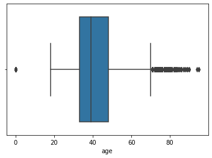

```python
sns.boxplot(data = df, x = 'age')
```

```python
Q1 = df['age'].quantile(0.25)
Q3 = df['age'].quantile(0.75)
IQR = Q3-Q1

print(Q1)
print(Q3)
print(IQR)

Lower_Whisker = Q1 - (1.5*IQR)
Upper_Whisker = Q3 + (1.5*IQR)

print(Lower_Whisker)
print(Upper_Whisker)
```

```
33.0
48.0
15.0
10.5
70.5
```

```python
df = df[df['age'] > Lower_Whisker]
df = df[df['age'] < Upper_Whisker]
```

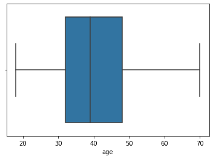

```python
sns.boxplot(data = df, x = 'age')
```

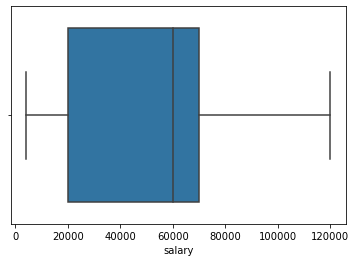

```python
sns.boxplot(data = df, x = 'salary')
```

#### OBSERVATION:

- There are no outliers in the salary column.

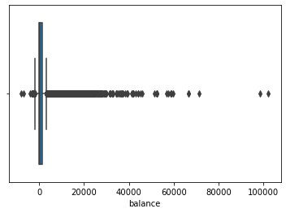

```python
sns.boxplot(data = df, x = 'balance')
```

```python
Q1 = df['balance'].quantile(0.25)
Q3 = df['balance'].quantile(0.75)
IQR = Q3-Q1

print(Q1)
print(Q3)
print(IQR)

Lower_Whisker = Q1 - (1.5*IQR)
Upper_Whisker = Q3 + (1.5*IQR)

print(Lower_Whisker)
print(Upper_Whisker)
```

```
69.0
1397.0
1328.0
-1923.0
3389.0
```

```python
df = df[df['balance'] > Lower_Whisker]
df = df[df['balance'] < Upper_Whisker]
```

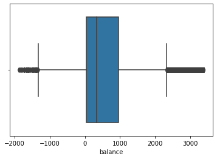

```python
sns.boxplot(data = df, x = 'balance')
```

#### OBSERVATION:

- There are outliers in the balance column.

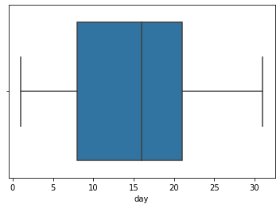

```python
sns.boxplot(data = df, x = 'day')
```

#### OBSERVATION:

- There are no outliers in the day column.

#### EXPLORATORY DATA ANALYSIS

- Exploratory Data Analysis (or) EDA is understanding the data sets by summarizing their main characteristics often plotting them visually.
- This step is very important especially when we arrive at modeling the data in order to apply Machine learning.

#### Why do we need EDA?

- An EDA is a thorough examination meant to uncover the underlying structure of a data set and is important for a company because it exposes trends, patterns, and relationships that are not readily apparent.

#### Why is EDA important in data science?

- The main purpose of EDA is to help look at data before making any assumptions.
- It can help identify obvious errors, as well as better understand patterns within the data, detect outliers or anomalous events, find interesting relations among the variables.
- During exploratory analysis, you focus on what has happened (information) and why it happened (knowledge).

#### What are the two goals of exploratory data analysis?

- The primary goal of EDA is to maximize the analyst's insight into a data set and into the underlying structure of a data set, while providing all of the specific items that an analyst would want to extract from a data set, such as: a good-fitting, parsimonious model. a list of outliers.

#### How do you do exploratory data analysis?

Some of the key steps in EDA are identifying the features, a number of observations, checking for null values or empty cells etc.

- Importing the dataset.
- Identifying the number of features or columns.
- Identifying the features or columns.
- Identifying the data types of features.
- Identifying the number of observations.

```python
df
```

|  | customer_id | age | salary | balance | marital | targeted | default | housing | loan | contact | ... | campaign | pdays | previous | poutcome | response | JOB | Edu | Month | Year | Duration |
| --- | --- | --- | --- | --- | --- | --- | --- | --- | --- | --- | --- | --- | --- | --- | --- | --- | --- | --- | --- | --- | --- |
| 0 | 1 | 58 | 100000 | 2143 | married | yes | no | yes | no | unknown | ... | 1 | -1 | 0 | unknown | no | management | tertiary | may | 2017 | 261.000000 |
| 1 | 2 | 44 | 60000 | 29 | single | yes | no | yes | no | unknown | ... | 1 | -1 | 0 | unknown | no | technician | secondary | may | 2017 | 151.000000 |
| 2 | 3 | 33 | 120000 | 2 | married | yes | no | yes | yes | unknown | ... | 1 | -1 | 0 | unknown | no | entrepreneur | secondary | may | 2017 | 76.000000 |
| 5 | 6 | 35 | 100000 | 231 | married | yes | no | yes | no | unknown | ... | 1 | -1 | 0 | unknown | no | management | tertiary | may | 2017 | 139.000000 |
| 6 | 7 | 28 | 100000 | 447 | single | no | no | yes | yes | unknown | ... | 1 | -1 | 0 | unknown | no | management | tertiary | may | 2017 | 217.000000 |
| ... | ... | ... | ... | ... | ... | ... | ... | ... | ... | ... | ... | ... | ... | ... | ... | ... | ... | ... | ... | ... | ... |
| 45203 | 45204 | 23 | 4000 | 113 | single | no | no | no | no | cellular | ... | 1 | -1 | 0 | unknown | yes | student | tertiary | nov | 2017 | 4.433333 |
| 45205 | 45206 | 25 | 60000 | 505 | single | yes | no | no | yes | cellular | ... | 2 | -1 | 0 | unknown | yes | technician | secondary | nov | 2017 | 6.433333 |
| 45206 | 45207 | 51 | 60000 | 825 | married | yes | no | no | no | cellular | ... | 3 | -1 | 0 | unknown | yes | technician | tertiary | nov | 2017 | 16.283333 |
| 45209 | 45210 | 57 | 20000 | 668 | married | yes | no | no | no | telephone | ... | 4 | -1 | 0 | unknown | no | collar | secondary | nov | 2017 | 8.466667 |
| 45210 | 45211 | 37 | 120000 | 2971 | married | yes | no | no | no | cellular | ... | 2 | 188 | 11 | other | no | entrepreneur | secondary | nov | 2017 | 6.016667 |

38236 rows × 22 columns

#### include = 'all' function:

- It is provided as an option, the result will include a union of attributes of each type.
- The includes and excludes parameters, can be used to limit which columns in a DataFrame are analyzed for the output.
- The parameters are ignored when analyzing a Series & describes a numeric Series.
- include: A white list of data types to include in the result.
- 'all' : All columns of the input will be included in the output.
- include = 'all': Describing all columns of a DataFrame regardless of data type.

```python
df.describe(include = "all")
```

|  | customer_id | age | salary | balance | marital | targeted | default | housing | loan | contact | ... | campaign | pdays | previous | poutcome | response | JOB | Edu | Month | Year | Duration |
| --- | --- | --- | --- | --- | --- | --- | --- | --- | --- | --- | --- | --- | --- | --- | --- | --- | --- | --- | --- | --- | --- |
| count | 38236.0 | 38236.000000 | 38236.000000 | 38236.000000 | 38236 | 38236 | 38236 | 38236 | 38236 | 38236 | ... | 38236 | 38236 | 38236.000000 | 38236 | 38236 | 38236 | 38236 | 38236 | 38236 | 38236.000000 |
| unique | 38236.0 | NaN | NaN | NaN | 3 | 2 | 2 | 2 | 2 | 3 | ... | 63 | 803 | NaN | 4 | 3 | 11 | 3 | 13 | 2 | NaN |
| top | 44182.0 | NaN | NaN | NaN | married | yes | no | yes | no | cellular | ... | 1 | -1 | NaN | unknown | no | collar | secondary | may | 2017 | NaN |
| freq | 1.0 | NaN | NaN | NaN | 22753 | 32815 | 37468 | 22021 | 31538 | 24910 | ... | 9806 | 25955 | NaN | 31434 | 34082 | 8502 | 20974 | 12140 | 38197 | NaN |
| mean | NaN | 40.130270 | 57178.784392 | 623.622999 | NaN | NaN | NaN | NaN | NaN | NaN | ... | NaN | NaN | 0.565540 | NaN | NaN | NaN | NaN | NaN | NaN | 84.674447 |
| std | NaN | 9.814391 | 31751.777660 | 826.184282 | NaN | NaN | NaN | NaN | NaN | NaN | ... | NaN | NaN | 2.345421 | NaN | NaN | NaN | NaN | NaN | NaN | 185.842820 |
| min | NaN | 18.000000 | 4000.000000 | -1884.000000 | NaN | NaN | NaN | NaN | NaN | NaN | ... | NaN | NaN | 0.000000 | NaN | NaN | NaN | NaN | NaN | NaN | 0.000000 |
| 25% | NaN | 32.000000 | 20000.000000 | 43.000000 | NaN | NaN | NaN | NaN | NaN | NaN | ... | NaN | NaN | 0.000000 | NaN | NaN | NaN | NaN | NaN | NaN | 2.216667 |
| 50% | NaN | 38.000000 | 60000.000000 | 338.500000 | NaN | NaN | NaN | NaN | NaN | NaN | ... | NaN | NaN | 0.000000 | NaN | NaN | NaN | NaN | NaN | NaN | 5.016667 |
| 75% | NaN | 47.000000 | 70000.000000 | 957.000000 | NaN | NaN | NaN | NaN | NaN | NaN | ... | NaN | NaN | 0.000000 | NaN | NaN | NaN | NaN | NaN | NaN | 97.000000 |
| max | NaN | 70.000000 | 120000.000000 | 3388.000000 | NaN | NaN | NaN | NaN | NaN | NaN | ... | NaN | NaN | 275.000000 | NaN | NaN | NaN | NaN | NaN | NaN | 3881.000000 |

11 rows × 22 columns

#### OBSERVATION:

- We are able to get the information of MEAN, MEDIAN, STANDARD DEVIATION, MINIMUM & MAXIMUM VALUES of the entire data.

```python
Maximum_Salary = df.salary.max()
Maximum_Salary
```

```
120000
```

```python
Minimum_Salary = df.salary.min()
Minimum_Salary
```

```
4000
```

```python
df.shape
```

```
(38236, 22)
```

```python
df.info()
```

```
<class 'pandas.core.frame.DataFrame'>
Int64Index: 38236 entries, 0 to 45210
Data columns (total 22 columns):
 #   Column       Non-Null Count  Dtype
---  ------       --------------  -----
 0   customer_id  38236 non-null  object
 1   age          38236 non-null  int32
 2   salary       38236 non-null  int32
 3   balance      38236 non-null  int32
 4   marital      38236 non-null  object
 5   targeted     38236 non-null  object
 6   default      38236 non-null  object
 7   housing      38236 non-null  object
 8   loan         38236 non-null  object
 9   contact      38236 non-null  object
 10  day          38236 non-null  int32
 11  duration     38236 non-null  object
 12  campaign     38236 non-null  object
 13  pdays        38236 non-null  object
 14  previous     38236 non-null  int32
 15  poutcome     38236 non-null  object
 16  response     38236 non-null  object
 17  JOB          38236 non-null  object
 18  Edu          38236 non-null  object
 19  Month        38236 non-null  object
 20  Year         38236 non-null  object
 21  Duration     38236 non-null  float64
dtypes: float64(1), int32(5), object(16)
memory usage: 6.0+ MB
```

#### COUNT PLOT:

- A count plot can be thought of as a histogram across a categorical, instead of quantitative, variable.
- The basic API and options are identical to those for barplot() , so you can compare counts across nested variables.
- countplot() method is used to Show the counts of observations in each categorical bin using bars.
- It simply shows the number of occurrences of an item based on a certain type of category.

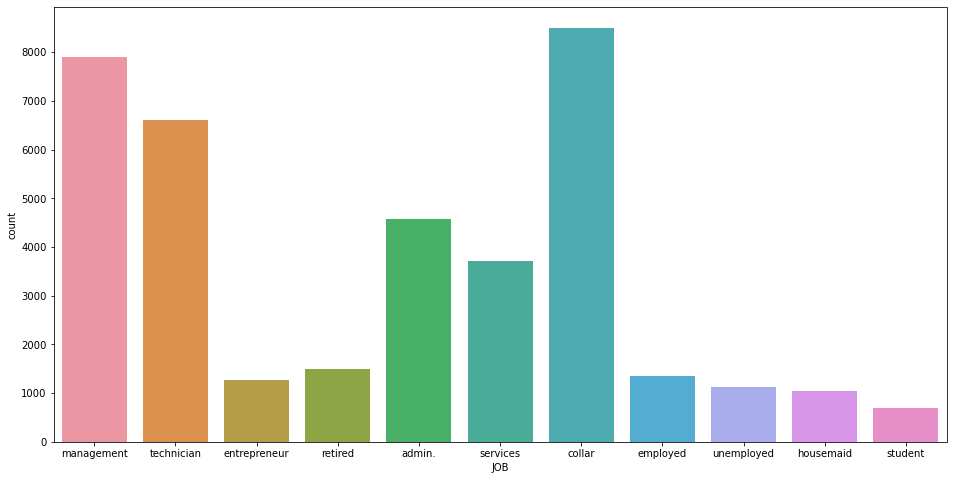

```python
plt.figure(figsize = (16, 8))
sns.countplot(data = df, x = 'JOB')
```

#### OBSERVATION:

- This Plot states that the maximum customers comes under management, collar and technician jobs and least were student, housemaid.

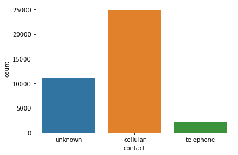

```python
sns.countplot(data = df, x = 'contact')
```

#### OBSERVATION:

- This states that the Customers are Contacting are high through cellular and least by telephone.

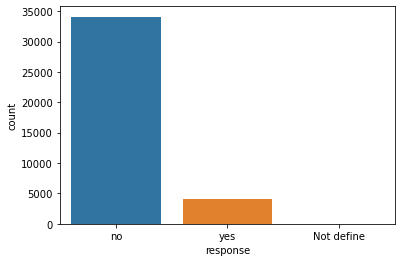

```python
sns.countplot(data = df, x = 'response')
```

#### OBSERVATION:

- There is no response from maximum customers on term deposits.

#### GENERAL OBSERVATIONS FROM THE COUNT PLOT:

- Vectors of data represented as lists, numpy arrays, or pandas Series objects passed directly to the x, y, and/or hue parameters.
- In most cases, it is possible to use numpy or Python objects, but pandas objects are preferable because the associated names will be used to annotate the axes.
- Additionally, we can use Categorical types for the grouping variables to control the order of plot elements.
- A "long-form" DataFrame, in which case the x, y, and hue variables will determine how the data are plotted.
- A “wide-form” DataFrame, such that each numeric column will be plotted.

#### BAR PLOT:

- A barplot (or barchart) is one of the most common type of plot.
- A bar graph is a chart that plots data using rectangular bars or columns (called bins) that represent the total amount of observations in the data for that category.
- It shows the relationship between a numerical variable and a categorical variable.
- For example, you can display the height of several individuals using bar chart.
- Barcharts are often confounded with.
- Each entity of the categoric variable is represented as a bar.
- The size of the bar represents its numeric value.
- Bar graphs are commonly used in financial analysis for displaying data.
- A stock volume chart is a commonly used type of vertical bar graph.

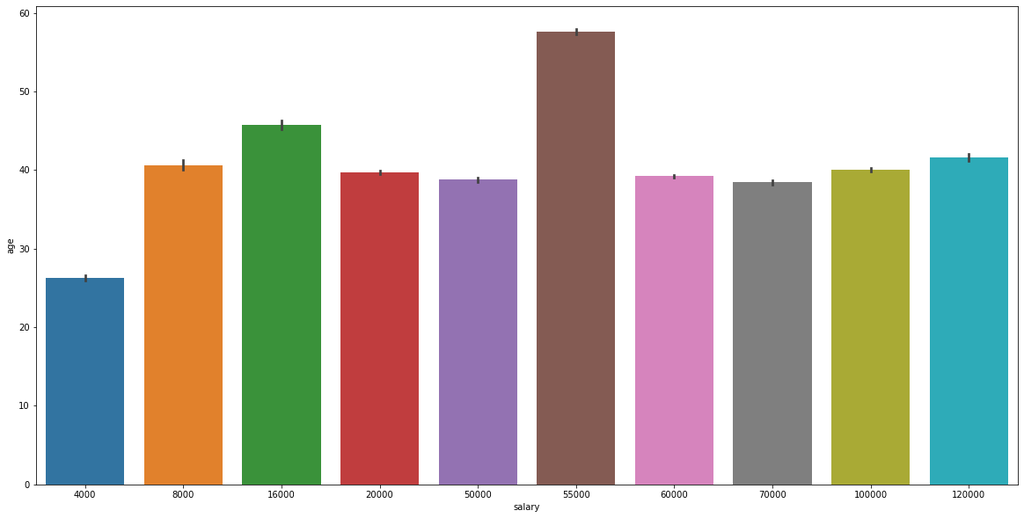

```python
plt.figure(figsize = (20, 10))
sns.barplot(data = df, x = 'salary', y = 'age')
```

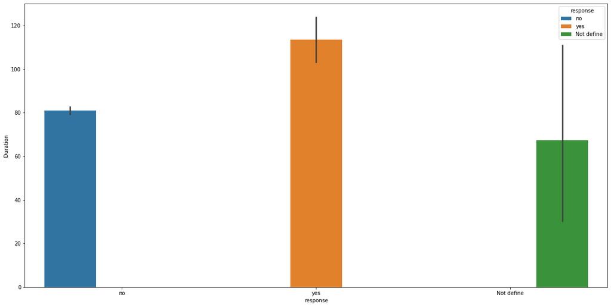

```python
plt.figure(figsize = (20, 10))
sns.barplot(data = df, x = 'response', y = 'Duration', hue = 'response')
```

#### OBSERVATION:

- This Plot states that if call duration is higher than the response of acceptance, then its high.

#### GENERAL OBSERVATIONS FROM THE BAR PLOT:

- They are created to show data in multiple, highly visual waysTo interpret the length of the bars/columns determines the value as described on the y-axis.
- Bar graphs have an x- and y-axis and can be used to showcase one, two, or many categories of data where Single and dual bar charts are practised using them to represent data to show the total size of groups.
- Shows how the proportions between groups related to each other, in addition to the total of each group.
- The columns can contain multiple labeled variables (or just one), or they can be grouped together (or not) for comparative purposes.

#### STRIP PLOT:

- A strip plot is a graphical data anlysis technique for summarizing a univariate data set.
- A strip plot is a scatter plot where one of the variables is categorical.
- They can be combined with other plots to provide additional information.
- The strip plot consists of: Horizontal axis = the value of the response variable.
- One problem with strip plots is how to display multiple points with the same value.

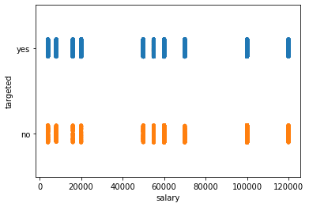

```python
sns.stripplot(data = df, x = 'salary', y = 'targeted')
```

#### GENERAL OBSERVATIONS FROM THE STRIP PLOT:

- Some things to keep an eye out for when looking at data on a numeric variable:
  1. Skewness and Multimodality can be seen, but other visualizations show these more clearly.
  2. Gaps and Outliers can be revealed and data outside of the expected range.
  3. rounding, e.g. to integer values, or heaping, i.e. a few particular values occur very frequently.
  4. impossible or suspicious values.
- Scalability in this form is limited due to over-plotting and can display up to 30,000 data points.
- With a good combination of point size choice, jittering, and alpha blending the strip plot for groups of data can scale to several hundred thousand observations and ten to twenty of groups.
- Storage needed for vector graphics images grows linearly with the number of observations.

#### BOX PLOT:

- Boxplots are a measure of how well distributed the data in a data set is.
- A box plot is a method for graphically depicting groups of numerical data through their quartiles. - The whiskers extend from the edges of box to show the range of the data.
- It divides the data set into three quartiles.
- This graph represents the minimum, maximum, median, first quartile and third quartile in the data set i.e., the box extends from the Q1 to Q3 quartile values of the data, with a line at the median (Q2).

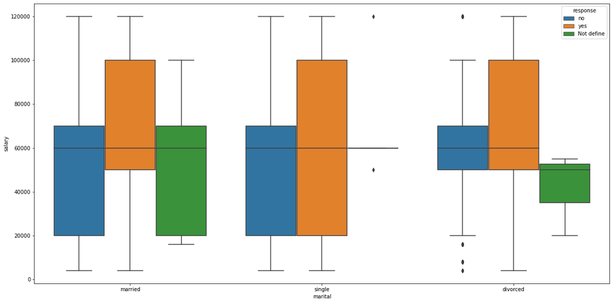

```python
plt.figure(figsize = (20, 10))
sns.boxplot(data = df, x = 'marital', y = 'salary', hue = 'response')
```

#### GENERAL OBSERVATIONS FROM THE BOX PLOT:

- Outliers
  1. An outlier is an observation that is numerically distant from the rest of the data.
  2. Box plots are useful as they show outliers within a data set.
  3. When reviewing a box plot, an outlier is defined as a data point that is located outside the whiskers of the box plot.
- Comparision of the medians, the interquartile ranges and whiskers of box plots.
- Gives the potential outliers and signs of Skewness.

#### BOXEN PLOT:

- It is similar to a box plot in plotting a nonparametric representation of a distribution in which all features correspond to actual observations.
- By plotting more quantiles, it provides more information about the shape of the distribution, particularly in the tails.
- Syntax : seaborn.boxenplot(parameters)

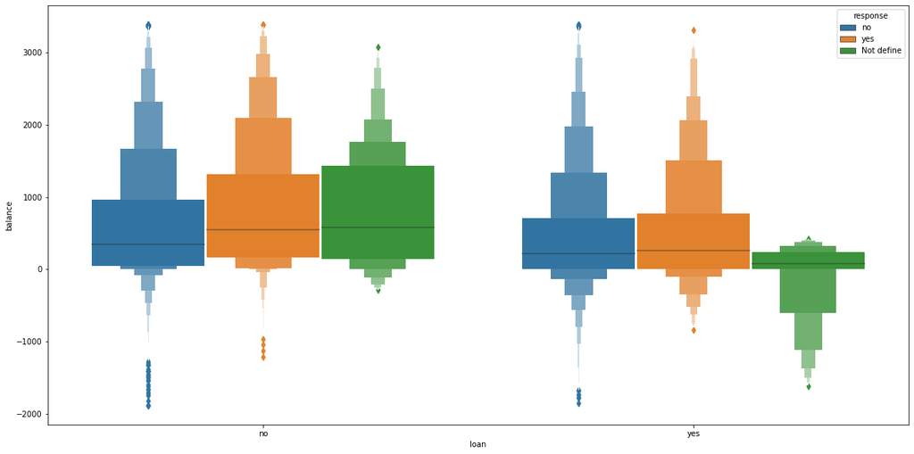

```python
plt.figure(figsize = (20, 10))
sns.boxenplot(data = df, x = 'loan', y = 'balance', hue = 'response')
```

#### OBSERVATION:

- This Plot states that Customers with no loan, customers with loan and having balance are accepting.

#### GENERAL OBSERVATIONS FROM THE BOXEN PLOT:

- Outliers.
  1. An outlier is an observation that is numerically distant from the rest of the data.
  2. Box plots are useful as they show outliers within a data set.
  3. When reviewing a box plot, an outlier is defined as a data point that is located outside the whiskers of the box plot.
- Comparision of the medians, the interquartile ranges and whiskers of box plots.
- Gives the potential outliers and signs of Skewness.

#### VIOLIN PLOT:

- A violin plot is a method of plotting numeric data.
- It is similar to a box plot, with the addition of a rotated kernel density plot on each side (or) A combination of boxplot and kernel density estimation, plays a similar role as a box and whisker plot.
- While a box plot only shows summary statistics such as mean/median and interquartile ranges, the violin plot shows the full distribution of the data.
- It shows the distribution of quantitative data across several levels of one (or) more categorical variables such that those distributions can be compared.

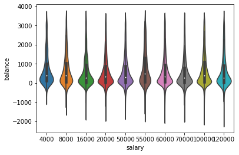

```python
sns.violinplot(x = df.salary, y = df.balance)
```

#### GENERAL OBSERVATIONS FROM THE VIOLIN PLOT:

- The white dot represents the median, the thick gray bar in the center represents the interquartile range, the thin gray line represents the rest of the distribution, except for points that are determined to be “outliers” using a method that is a function of the interquartile range.
- Violin plot are made vertically most of the time, If you have long labels building an horizontal version like above make the labels more readable.
- If the variable are grouped, we can build a grouped violin as you would do for a boxplot.

#### PIE CHART:

- A pie chart (or a circle chart) is a circular statistical plot, that can display only one series of data which is divided into slices to illustrate numerical proportion.
- The area of the chart is the total percentage of the given data.
- The arc length of each slice (and consequently its central angle and area), is proportional to the quantity it represents.
- While it is named for its resemblance to a pie which has been sliced, there are variations on the way it can be presented.
- The slices of pie are called wedges.

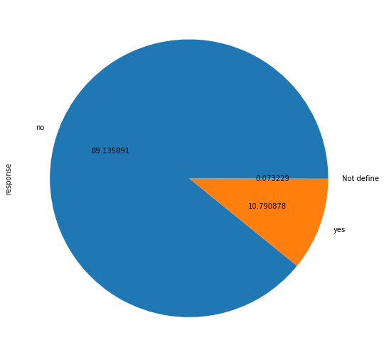

```python
df.response.value_counts().plot(kind = 'pie', autopct = '%2f', figsize = (9, 9))
```

#### OBSERVATION:

- This Pie-Chart shows that there is no response from maximum customers about term deposit.

#### GENERAL OBSERVATIONS FROM THE PIE CHART:

- When you interpret one pie chart, we get the differences in the size of the slices as per the data taken.
- The size of a slice shows the proportion of observations that are in that group.
- When you compare multiple pie charts, we get the differences in the size of slices for the same categories in all the pie charts.

#### CHI-SQUARE TEST

- A chi-square (χ2) statistic is a test that measures how a model compares to actual observed data.
- The chi-square statistic compares the size any discrepancies between the expected results and the actual results, given the size of the sample and the number of variables in the relationship.

#### What are chi square test and when do we use it?

- The Chi-Square Test of Independence determines whether there is an association between categorical variables i.e., whether the variables are independent (or) related.
- It is a nonparametric test.
- This test is also known as: Chi-Square Test of Association.

#### When chi square test is applicable?

- The test is applied when you have two categorical variables from a single population.
- It is used to determine whether there is a significant association between the two variables.

#### What are the three chi square tests?

- There are three types of Chi-square tests:
  1. Tests of goodness of fit, independence and homogeneity.
  2. All three tests also rely on the same formula to compute a test statistic.

#### How do you interpret a chi square test?

- For a Chi-square test, a p-value that is less than or equal to your significance level indicates there is sufficient evidence to conclude that the observed distribution is not the same as the expected distribution.
- We can conclude that a relationship exists between the categorical variables.

#### What is a good chi square value?

- If the significance value that is p-value associated with chi-square statistics is 0.002, there is very strong evidence of rejecting the null hypothesis of no fit.
- It means good fit.

#### What are the advantages of chi square test?

- Advantages of the Chi-square include its robustness with respect to distribution of the data.
- Its ease of computation, the detailed information that can be derived from the test.
- Its use in studies for which parametric assumptions cannot be met and flexibile in handling data from both two group and multiple.

#### What are the disadvantages of chi square test?

- First, chi-square is highly sensitive to sample size.
- As sample size increases, absolute differences become a smaller and smaller proportion of the expected value.
- Generally when the expected frequency in a cell of a table is less than 5, chi-square can lead to erroneous conclusions.

#### What are the limitations of chi square test?

- One of the limitations is that all participants measured must be independent, meaning that an individual cannot fit in more than one category.
- If a participant can fit into two categories a chi-square analysis is not appropriate.
- Limitations include its sample size requirements, difficulty of interpretation when there are large numbers of categories (20 or more) in the independent or dependent variables.
- The tendency of the Cramer's V to produce relative low correlation measures, even for highly significant results.

```python
from scipy.stats import chi2
from scipy.stats import chi2_contingency
```

```python
pd.crosstab(df['poutcome'], df['response'], margins = True)
```

| response poutcome | Not define | no | yes | All |
| --- | --- | --- | --- | --- |
| failure | 4 | 3611 | 481 | 4096 |
| other | 1 | 1317 | 233 | 1551 |
| success | 1 | 415 | 739 | 1155 |
| unknown | 22 | 28739 | 2673 | 31434 |
| All | 28 | 34082 | 4126 | 38236 |

```python
observed = pd.crosstab(df['poutcome'], df['response'])
observed
```

| response poutcome | Not define | no | yes |
| --- | --- | --- | --- |
| failure | 4 | 3611 | 481 |
| other | 1 | 1317 | 233 |
| success | 1 | 415 | 739 |
| unknown | 22 | 28739 | 2673 |

#### CHI2_CONTINGENCY:

- chi2*contingency (observed, correction = True, lambda*= None).
- Chi-square test of independence of variables in a contingency table.
- This function computes the chi-square statistic and p-value for the hypothesis test of independence of the observed frequencies in the contingency table observed.

```python
chi2_contingency(observed)
```

```
(3599.2723401352414,
 0.0,
 6,
 array([[2.99947693e+00, 3.65100617e+03, 4.41994351e+02],
        [1.13578826e+00, 1.38249770e+03, 1.67366513e+02],
        [8.45799770e-01, 1.02951956e+03, 1.24634638e+02],
        [2.30189350e+01, 2.80189766e+04, 3.39200450e+03]]))
```

```python
chi2_test_stat = chi2_contingency(observed)[0]
pval = chi2_contingency(observed)[1]
dof = chi2_contingency(observed)[2]
```

```python
alpha = 1 - 0.90
chi2_critical = chi2.ppf(1 - alpha, dof)
chi2_critical
```

```
10.644640675668422
```

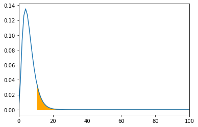

```python
x_min = 0
x_max = 100

x = np.linspace(x_min, x_max, 100)
y = chi2.pdf(x, dof)

plt.xlim(x_min, x_max)
plt.plot(x, y)

chi2_critical_right = chi2_critical

x1 = np.linspace(chi2_critical_right, x_max, 100)
y1 = chi2.pdf(x1, dof)

plt.fill_between(x1, y1, color = 'orange')
```

#### REJECT NULL HYPOTHESIS:

- When your p-value is less than or equal to your significance level, you reject the null hypothesis.
- The data favors the alternative hypothesis.
- Our results are statistically significant.
- When your p-value is greater than your significance level, you fail to reject the null hypothesis.

#### What does rejecting the null hypothesis mean?

- In null hypothesis testing, this criterion is called α (alpha) and is almost always set to.
- If there is less than a 5% chance of a result as extreme as the sample result if the null hypothesis were true, then the null hypothesis is rejected.
- When this happens, the result is said to be statistically significant.

#### How do you reject or accept the null hypothesis?

- In Hypothesis testing, if the significance value of the test is greater than the predetermined significance level, then we accept the null hypothesis.
- If the significance value is less than the predetermined value, then we should reject the null hypothesis.

```python
if(chi2_test_stat > chi2_critical):
    print("Reject Null Hypothesis")
else:
    print("Fail to Reject Null Hypothesis")
```

```
Reject Null Hypothesis
```

```python
if(pval < alpha):
    print("Reject Null Hypothesis")
else:
    print("Fail to Reject Null Hypothesis")
```

```
Reject Null Hypothesis
```

#### CONCLUSION:

- The two possible verdicts are similar to the two conclusions that are possible in a hypothesis test.
- Reject the null hypothesis: When we reject a null hypothesis, we accept the alternative hypothesis.
- This is like a guilty verdict.
- The evidence is strong enough for the jury to reject the assumption of innocence.